# Practical Machine Learning Final

Eliza

September 24, 2015

The scripts have been solely produced, tested and executed on MAC OS X 10.10.5, and RStudio Version 0.99.465.

## Executive Summary

In this assignment I will be using machine learning to determine how test subjects completed a barbell activity. First the data was cleaned, then analyzed in an Exploratory manner (see Figure 2 in the Appendix). It was determined that a Random Forest method worked the best with this type of data as determined by the accuracy rate (for comparison with a Decision Tree Model, see Figure 1 in the Appendix). The algorithm was then applied to the test data and passed the given submission values with a success rate of 100%.

## Introduction

Using devices such as Jawbone Up, Nike FuelBand, and Fitbit it is now possible to collect a large amount of data about personal activity relatively inexpensively. These type of devices are part of the quantified self movement – a group of enthusiasts who take measurements about themselves regularly to improve their health, to find patterns in their behavior, or because they are tech geeks. One thing that people regularly do is quantify how much of a particular activity they do, but they rarely quantify how well they do it. In this project, your goal will be to use data from accelerometers on the belt, forearm, arm, and dumbell of 6 participants. They were asked to perform barbell lifts correctly and incorrectly in 5 different ways. More information is available from the website here: http://groupware.les.inf.puc-rio.br/har (see the section on the Weight Lifting Exercise Dataset).

## Analysis

### Data and Libraries

The following libraries were needed for the various parts of the project, and I decided to load them all at once. I also set the seed so that my results would be reproducible.

```r
library(caret)
```

```r
library(rpart)
library(rpart.plot)
library(RColorBrewer)
library(rattle)
library(randomForest)
library(corrplot)
set.seed(10000)
```

I then loaded the training and testing dataset so that it would be stored in the memory only.

```r
trainUrl <- "https://d396qusza40orc.cloudfront.net/predmachlearn/pml-training.csv"
testUrl <- "https://d396qusza40orc.cloudfront.net/predmachlearn/pml-testing.csv"

# Load data

training <- read.csv(url(trainUrl), na.strings=c("NA","#DIV/0!",""))
testing <- read.csv(url(testUrl), na.strings=c("NA","#DIV/0!",""))
```

### Partioning the training set

Partioning Training data set into two data sets, 60% for trainData, 40% for testData. This is essentially creating a validation dataset so that we apply our algorithm to the test dataset only once and prevent overfitting.

```r
inTrain <- createDataPartition(y=training$classe, p=0.6, list=FALSE)
trainData <- training[inTrain, ]; testData <- training[-inTrain, ]
dim(trainData); dim(testData)
```

```
## [1] 11776   160
```

```
## [1] 7846  160
```

### Cleaning the data

The code below transformed the data into a tidy dataset that can be used in machine learning algorithms. The following 3 transformations were applied.

1. Cleaning Variables with little or no variance as they are not valuable as predictors of the outcome
2. Removing the ID variable as it is not a predictor
3. Removing variables with too many NA’s (chosen threshold was 50%)

```r
# Transformation 1

myNZVvars <- names(trainData) %in% c("new_window", "kurtosis_roll_belt", "kurtosis_picth_belt",
"kurtosis_yaw_belt", "skewness_roll_belt", "skewness_roll_belt.1", "skewness_yaw_belt",
"max_yaw_belt", "min_yaw_belt", "amplitude_yaw_belt", "avg_roll_arm", "stddev_roll_arm",
"var_roll_arm", "avg_pitch_arm", "stddev_pitch_arm", "var_pitch_arm", "avg_yaw_arm",
"stddev_yaw_arm", "var_yaw_arm", "kurtosis_roll_arm", "kurtosis_picth_arm",
"kurtosis_yaw_arm", "skewness_roll_arm", "skewness_pitch_arm", "skewness_yaw_arm",
"max_roll_arm", "min_roll_arm", "min_pitch_arm", "amplitude_roll_arm", "amplitude_pitch_arm",
"kurtosis_roll_dumbbell", "kurtosis_picth_dumbbell", "kurtosis_yaw_dumbbell", "skewness_roll_dumbbell",
"skewness_pitch_dumbbell", "skewness_yaw_dumbbell", "max_yaw_dumbbell", "min_yaw_dumbbell",
"amplitude_yaw_dumbbell", "kurtosis_roll_forearm", "kurtosis_picth_forearm", "kurtosis_yaw_forearm",
"skewness_roll_forearm", "skewness_pitch_forearm", "skewness_yaw_forearm", "max_roll_forearm",
"max_yaw_forearm", "min_roll_forearm", "min_yaw_forearm", "amplitude_roll_forearm",
"amplitude_yaw_forearm", "avg_roll_forearm", "stddev_roll_forearm", "var_roll_forearm",
"avg_pitch_forearm", "stddev_pitch_forearm", "var_pitch_forearm", "avg_yaw_forearm",
"stddev_yaw_forearm", "var_yaw_forearm")
trainData <- trainData[!myNZVvars]

# Transformation 2
trainData <- trainData[c(-1)]

# Transformation 3
trainingV3 <- trainData
for(i in 1:length(trainData)) {
        if( sum( is.na( trainData[, i] ) ) /nrow(trainData) >= .5 ) {
        for(j in 1:length(trainingV3)) {
            if( length( grep(names(trainData[i]), names(trainingV3)[j]) ) ==1)  {
                trainingV3 <- trainingV3[ , -j]
            }
        }
    }
}
#C heck the new dimensions of observations
dim(trainingV3)
```

```
## [1] 11776    58
```

```r
#Setting back to our set:
trainData <- trainingV3
rm(trainingV3)
str(trainData)
```

```
## 'data.frame':    11776 obs. of  58 variables:
##  $ user_name           : Factor w/ 6 levels "adelmo","carlitos",..: 2 2 2 2 2 2 2 2 2 2 ...
##  $ raw_timestamp_part_1: int  1323084231 1323084231 1323084232 1323084232 1323084232 1323084232 1323084232 1323084232 1323084232 1323084232 ...
##  $ raw_timestamp_part_2: int  808298 820366 120339 368296 440390 528316 576390 692324 788335 892313 ...
##  $ cvtd_timestamp      : Factor w/ 20 levels "02/12/2011 13:32",..: 9 9 9 9 9 9 9 9 9 9 ...
##  $ num_window          : int  11 11 12 12 12 12 12 12 12 12 ...
##  $ roll_belt           : num  1.41 1.42 1.48 1.42 1.42 1.43 1.42 1.51 1.59 1.57 ...
##  $ pitch_belt          : num  8.07 8.07 8.05 8.09 8.13 8.18 8.21 8.12 8.07 8.09 ...
##  $ yaw_belt            : num  -94.4 -94.4 -94.4 -94.4 -94.4 -94.4 -94.4 -94.4 -94.4 -94.4 ...
##  $ total_accel_belt    : int  3 3 3 3 3 3 3 3 3 3 ...
##  $ gyros_belt_x        : num  0.02 0 0.02 0.02 0.02 0.02 0.02 0 0.02 0.02 ...
##  $ gyros_belt_y        : num  0 0 0 0 0 0 0 0 0 0.02 ...
##  $ gyros_belt_z        : num  -0.02 -0.02 -0.03 -0.02 -0.02 -0.02 -0.02 -0.02 -0.02 -0.02 ...
##  $ accel_belt_x        : int  -22 -20 -22 -22 -22 -22 -22 -21 -22 -21 ...
##  $ accel_belt_y        : int  4 5 3 3 4 2 4 4 5 3 ...
```

[output cut: 44 more lines]

We need to remember to apply the same set of transformations to the testing dataset.

```r
clean1 <- colnames(trainData)
clean2 <- colnames(trainData[, -58]) #already with classe column removed
testData <- testData[clean1]
testing <- testing[clean2]
```

To ensure full functionality of Decision Trees and especially the Random Forest Algorithm with the Test data set, I coerced the data into the same type.

```r
for (i in 1:length(testing) ) {
        for(j in 1:length(trainData)) {
        if( length( grep(names(trainData[i]), names(testing)[j]) ) ==1)  {
            class(testing[j]) <- class(trainData[i])
        }
    }
}
#And to make sure Coercion really worked
testing <- rbind(trainData[2, -58] , testing)
testing <- testing[-1,]
```

### Random Forests Prediction Algorithm

```r
controlRf <- trainControl(method="cv", 5)
modFitB1 <- randomForest(classe ~. , data=trainData, trControl=controlRf)
# Predicting in-sample error:
predictionsB1 <- predict(modFitB1, testData, type = "class")
c2 <- confusionMatrix(predictionsB1, testData$classe)
c2
```

```
## Confusion Matrix and Statistics
##
##           Reference
## Prediction    A    B    C    D    E
##          A 2231    2    0    0    0
##          B    1 1516    2    0    0
##          C    0    0 1366    3    0
##          D    0    0    0 1281    1
##          E    0    0    0    2 1441
##
## Overall Statistics
##
##                Accuracy : 0.9986
##                  95% CI : (0.9975, 0.9993)
##     No Information Rate : 0.2845
##     P-Value [Acc > NIR] : < 2.2e-16
##
##                   Kappa : 0.9982
##  Mcnemar's Test P-Value : NA
##
## Statistics by Class:
##
##                      Class: A Class: B Class: C Class: D Class: E
## Sensitivity            0.9996   0.9987   0.9985   0.9961   0.9993
## Specificity            0.9996   0.9995   0.9995   0.9998   0.9997
## Pos Pred Value         0.9991   0.9980   0.9978   0.9992   0.9986
## Neg Pred Value         0.9998   0.9997   0.9997   0.9992   0.9998
## Prevalence             0.2845   0.1935   0.1744   0.1639   0.1838
## Detection Rate         0.2843   0.1932   0.1741   0.1633   0.1837
## Detection Prevalence   0.2846   0.1936   0.1745   0.1634   0.1839
## Balanced Accuracy      0.9996   0.9991   0.9990   0.9980   0.9995
```

## Conclusions and Submission

Finally, I used the provided Test Set out-of-sample error.

```r
predictionsB2 <- predict(modFitB1, testing, type = "class")
predictionsB2
```

```
##  2 31  4  5  6  7  8  9 10 11 12 13 14 15 16 17 18 19 20 21
##  B  A  B  A  A  E  D  B  A  A  B  C  B  A  E  E  A  B  B  B
## Levels: A B C D E
```

The predictions were accurate 100% of the time although there were only 20 cases. Below is a function to generate files with predictions to submit for assignment. Since this was used only once, it is commented out so that the code may be seen but new files are not generated each time.

```r
# pml_write_files = function(x){
#   n = length(x)
#   for(i in 1:n){
#     filename = paste0("problem_results/problem_id_",i,".txt")
#     write.table(x[i],file=filename,quote=FALSE,row.names=FALSE,col.names=FALSE)
#   }
# }
#
# pml_write_files(predictionsB2)
```

## Appendix

### Decision Tree Prediction algroithm

The decision tree algorithm is to ensure that I picked the best model. The Accuracy rate from the Confusion Matrix is acceptable but not optimal.

[figure not shown]

```r
modFitA1 <- rpart(classe ~ ., data=trainData, method="class")
fancyRpartPlot(modFitA1)
```

Predicting:

```r
predictionsA1 <- predict(modFitA1, testData, type = "class")
confusionMatrix(predictionsA1, testData$classe)
```

```
## Confusion Matrix and Statistics
##
##           Reference
## Prediction    A    B    C    D    E
##          A 2150   60    7    1    0
##          B   61 1260   69   64    0
##          C   21  188 1269  143    4
##          D    0   10   14  857   78
##          E    0    0    9  221 1360
##
## Overall Statistics
##
##                Accuracy : 0.8789
##                  95% CI : (0.8715, 0.8861)
##     No Information Rate : 0.2845
##     P-Value [Acc > NIR] : < 2.2e-16
##
##                   Kappa : 0.8468
##  Mcnemar's Test P-Value : NA
##
## Statistics by Class:
##
##                      Class: A Class: B Class: C Class: D Class: E
## Sensitivity            0.9633   0.8300   0.9276   0.6664   0.9431
## Specificity            0.9879   0.9693   0.9450   0.9845   0.9641
## Pos Pred Value         0.9693   0.8666   0.7809   0.8936   0.8553
## Neg Pred Value         0.9854   0.9596   0.9841   0.9377   0.9869
## Prevalence             0.2845   0.1935   0.1744   0.1639   0.1838
## Detection Rate         0.2740   0.1606   0.1617   0.1092   0.1733
## Detection Prevalence   0.2827   0.1853   0.2071   0.1222   0.2027
## Balanced Accuracy      0.9756   0.8997   0.9363   0.8254   0.9536
```

### Correlation Plot

The correlation matrix is able to show relationships among the variables in the predictor data for exploratory purposes.

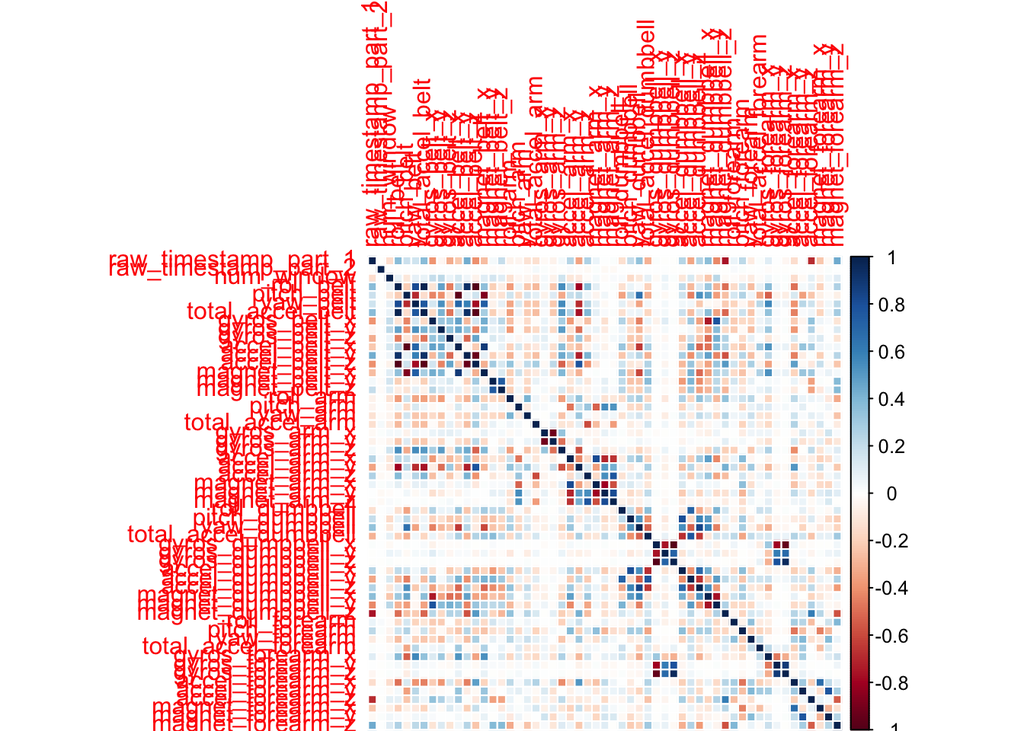

```r
corData <- trainData[-1,-1]
corData <- corData[,-length(corData)]
corData <- corData[,sapply(corData, is.numeric)]
corrPlot <- cor(corData)
corrplot(corrPlot, method="color")
```